# Measuring Classification Performance

Przemyslaw Biecek, Anna Wróblewska

Data Mining - Advances

# Preparing data for classification task

At first try if your data is imbalanced regarding target variable. Check if there are some problematic variables.

```r
library(faraway)
library(caret)
library(dplyr)
pima$test <- factor(pima$test)

prop.table(table(pima$test))
```

```
##
##         0         1
## 0.6510417 0.3489583
```

```r
lapply(pima %>% select(glucose,pregnant,test), function(x) data.frame(table(x)))
```

```
## $glucose
##       x Freq
## 1     0    5
## 2    44    1
## 3    56    1
## 4    57    2
## 5    61    1
## 6    62    1
## 7    65    1
## 8    67    1
## 9    68    3
## 10   71    4
## 11   72    1
## 12   73    3
## 13   74    4
```

[output cut: 148 more lines]

```r
#problematic features with near zero variance
nearZeroVar(pima, saveMetrics = TRUE)
```

```
##           freqRatio percentUnique zeroVar   nzv
## pregnant   1.216216     2.2135417   FALSE FALSE
## glucose    1.000000    17.7083333   FALSE FALSE
## diastolic  1.096154     6.1197917   FALSE FALSE
## triceps    7.322581     6.6406250   FALSE FALSE
## insulin   34.000000    24.2187500   FALSE FALSE
## bmi        1.083333    32.2916667   FALSE FALSE
## diabetes   1.000000    67.3177083   FALSE FALSE
## age        1.142857     6.7708333   FALSE FALSE
## test       1.865672     0.2604167   FALSE FALSE
```

```r
#there are no correlated features
d.num <- pima %>% select(which(sapply(pima, is.numeric))) # only numeric features
high.corr.num <- findCorrelation(cor(d.num), cutoff = .75)
names(d.num)[high.corr.num]
```

```
## character(0)
```

Normalize input data if they are numeric, continuous and if you use a classfier that uses numeric equations. Generally normalization is useful, when you are solving a system of equations, least squares, etc, where you can have serious issues due to rounding errors.

```r
pre_processed_data <- preProcess(pima, method = c("center", "scale"))
pre_processed_pima <- predict(pre_processed_data, pima)
```

# Measuring classification performance

```r
library(party)
diabTree <- ctree(test ~ ., data = pima)
diabTree
```

```
##
##   Conditional inference tree with 7 terminal nodes
##
## Response:  test
## Inputs:  pregnant, glucose, diastolic, triceps, insulin, bmi, diabetes, age
## Number of observations:  768
##
## 1) glucose <= 127; criterion = 1, statistic = 166.975
##   2) age <= 28; criterion = 1, statistic = 28.915
##     3) bmi <= 30.9; criterion = 0.999, statistic = 14.419
##       4) pregnant <= 5; criterion = 0.993, statistic = 11.077
##         5)*  weights = 144
##       4) pregnant > 5
##         6)*  weights = 7
##     3) bmi > 30.9
##       7)*  weights = 120
##   2) age > 28
##     8)*  weights = 214
## 1) glucose > 127
##   9) glucose <= 154; criterion = 1, statistic = 26.787
##     10) bmi <= 29.9; criterion = 1, statistic = 20.552
##       11)*  weights = 53
##     10) bmi > 29.9
##       12)*  weights = 108
##   9) glucose > 154
##     13)*  weights = 122
```

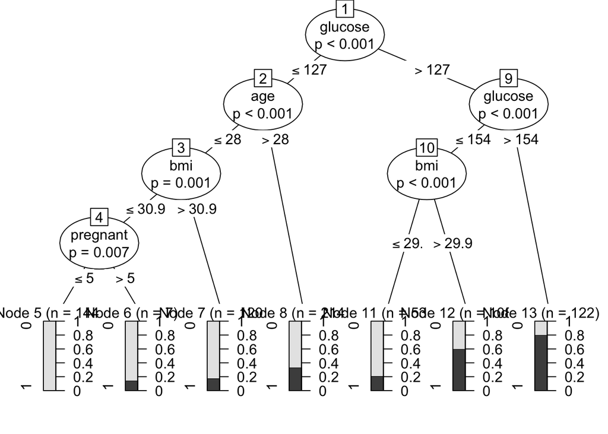

```r
plot(diabTree)
```

```r
predicted.pima = predict(diabTree)
tab<-table(real = pima$test,
      predicted = predicted.pima)
tab
```

```
##     predicted
## real   0   1
##    0 433  67
##    1 105 163
```

```r
#Accuracy
mean(pima$test == predict(diabTree))
```

```
## [1] 0.7760417
```

```r
sum(diag(tab)) / sum(tab)
```

```
## [1] 0.7760417
```

# Contingency Tables

The most common performance measures consider the model’s ability to differentiate between classess, i.e. one class versus all other classess in mulitlabel case. One class is called positive class and the other (the others) - negative class. The model’s predictions fall into one of four categories:

- True positive (TP) - Correctly classified as the class of interest
- True negative (TN) - Correctly classified as not the class of interest
- False positive (FP) - Incorrectly classified as the class of interest
- False negative (FN) - Incorrectly classfied as not the class of interest

The schema of contingency table is as follows:

| 0 | 1 |  
— | —– | —-: |  
0 | TN | FP |  
1 | FN | TP |

```r
library(gmodels)
ctab<-CrossTable(pima$test,predicted.pima)
```

```
##
##
##    Cell Contents
## |-------------------------|
## |                       N |
## | Chi-square contribution |
## |           N / Row Total |
## |           N / Col Total |
## |         N / Table Total |
## |-------------------------|
##
##
## Total Observations in Table:  768
##
##
##              | predicted.pima
##    pima$test |         0 |         1 | Row Total |
## -------------|-----------|-----------|-----------|
##            0 |       433 |        67 |       500 |
##              |    19.545 |    45.718 |           |
##              |     0.866 |     0.134 |     0.651 |
##              |     0.805 |     0.291 |           |
##              |     0.564 |     0.087 |           |
## -------------|-----------|-----------|-----------|
##            1 |       105 |       163 |       268 |
##              |    36.465 |    85.295 |           |
##              |     0.392 |     0.608 |     0.349 |
##              |     0.195 |     0.709 |           |
##              |     0.137 |     0.212 |           |
## -------------|-----------|-----------|-----------|
## Column Total |       538 |       230 |       768 |
##              |     0.701 |     0.299 |           |
## -------------|-----------|-----------|-----------|
##
##
```

```r
ctab
```

```
## $t
##    y
## x     0   1
##   0 433  67
##   1 105 163
##
## $prop.row
##    y
## x          0        1
##   0 0.866000 0.134000
##   1 0.391791 0.608209
##
## $prop.col
##    y
## x           0         1
##   0 0.8048327 0.2913043
##   1 0.1951673 0.7086957
##
## $prop.tbl
##    y
## x            0          1
##   0 0.56380208 0.08723958
##   1 0.13671875 0.21223958
```

Basic measures are as follows:

$Accuracy = \frac{TP + TN }{TP + TN + FP + FN}$

Accuracy is the sum of diagonals of a contingency table.

$Error rate = \frac{FP+FN}{TP + TN + FP + FN} = 1 - Accuracy$

# Kappa

Kappa statistics takes into account the agreement occurring by chance and is proper for imbalanced input datasets. Imbalanced datasets occure when the is substantial difference between number of examples in target classes, e.g. a large majority samples belongs to one class. For example in screening mammography there are 2 cases of breast cancer among above 100 000 examples for health mammograms. Simple accuracy does not work in this case, i.e. it will be very high even for any classifier will predict only healthy cases.

The equation for $\kappa$ is:

$\kappa = \frac{p_o - p_e}{1 - p_e} = 1- \frac{1 - p_o}{1 - p_e},$

where $p_o$ is the observed agreement between the classifier and the true values, and $p_e$ is the hypothetical probability of chance agreement, using the observed data to calculate the probabilities of each observer randomly saying each predicted category.

https://en.wikipedia.org/wiki/Cohen%27s_kappa

To calculate the observed agreement, we add the proportion of all instances when the predicted type and actual type agree.

```r
a<-ctab$prop.tbl
p_o <- ctab$prop.tbl[1,1] + ctab$prop.tbl[2,2]
p_o
```

```
## [1] 0.7760417
```

```r
p_e <- (ctab$prop.tbl[1,1]+ctab$prop.tbl[2,1]) * (ctab$prop.tbl[1,1]+ctab$prop.tbl[1,2]) +
       (ctab$prop.tbl[2,1]+ctab$prop.tbl[2,2]) * (ctab$prop.tbl[1,2]+ctab$prop.tbl[2,2])
p_e
```

```
## [1] 0.560574
```

```r
kappa = (p_o - p_e) / (1 - p_e)

library(vcd)
#unweighted value
Kappa(table(real = pima$test, predicted = predicted.pima))
```

```
##             value     ASE    z Pr(>|z|)
## Unweighted 0.4903 0.03335 14.7    6e-49
## Weighted   0.4903 0.03335 14.7    6e-49
```

```r
library(irr)
kappa2(data.frame(pima$test, predicted.pima))
```

```
##  Cohen's Kappa for 2 Raters (Weights: unweighted)
##
##  Subjects = 768
##    Raters = 2
##     Kappa = 0.49
##
##         z = 13.7
##   p-value = 0
```

# Other metrics

Sensitivity of a model measures the proportion of positive examples that were correctly classified to all examples that are positive.

$Sensitivity = /frac{TP}{TP+FN}$

Specificity of a model measures the proportion of not correcly classified examples to all misclassifications.

$Specificity = /frac{TN}{TN+FP}$

Any ROC curve shows the dependency of sensitivity to 1-specificity.

# ROC (Receiver Operating Characteristics)

Classifiers that calculate scores / probabilities may be examined with the use of so called ROC. Let’s see an simple example for the trained random forest.

```r
library(randomForest)
ffit <- randomForest(test ~ .,   data=pima, importance = TRUE)
prob <- predict(ffit, type="prob")[,2]

library(ROCR)
```

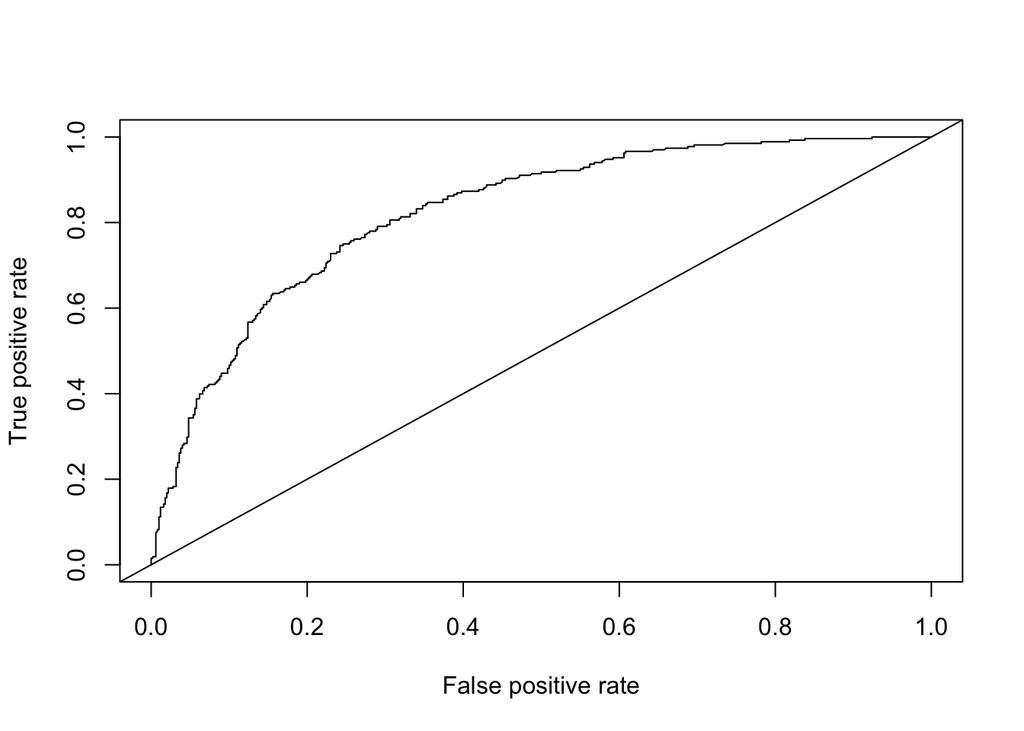

```r
fit.pred = prediction(prob, pima$test)
fit.perf = performance(fit.pred,"tpr","fpr")
plot(fit.perf)
abline(a=0,b=1)
```

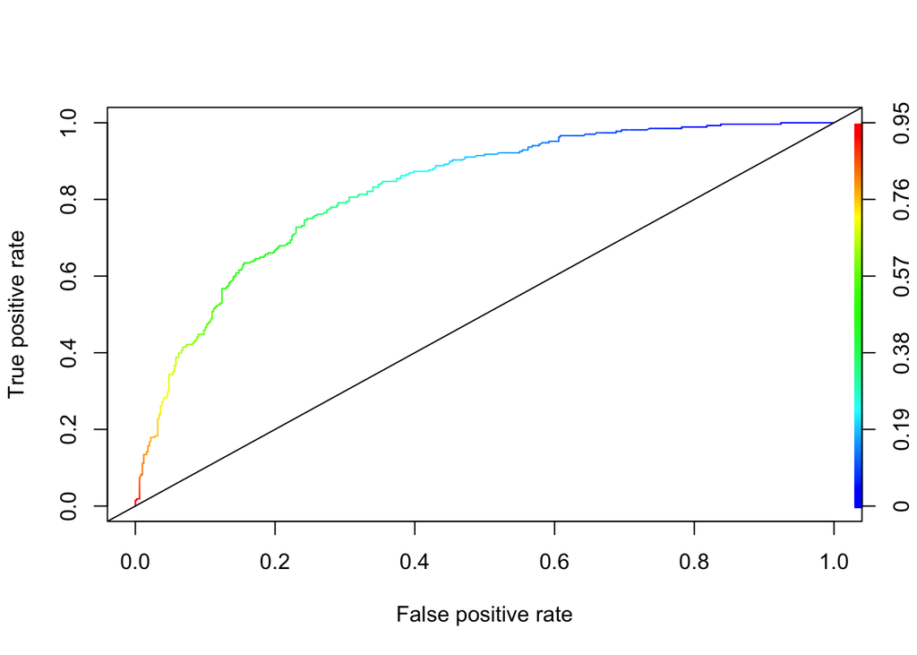

```r
fit.pred = prediction(prob, pima$test)
fit.perf = performance(fit.pred,"tpr","fpr")
plot(fit.perf, colorize=TRUE)
abline(a=0,b=1)
```

# Multiple curves

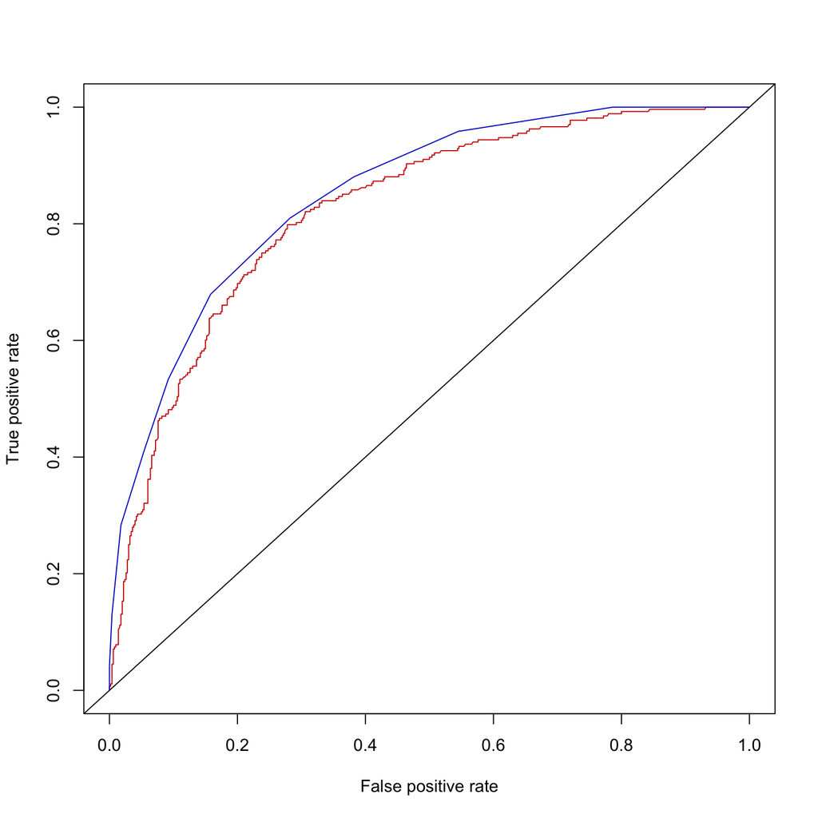

```r
library(caret)

ffit <- randomForest(test ~ .,   data=pima, importance = TRUE, mtry=3)
prob <- predict(ffit, type="prob")[,2]

ffit2 <- knn3(test ~ .,   data=pima, k=10)
prob2 <- predict(ffit2, newdata = pima, type="prob")[,2]

fit.pred = prediction(prob, pima$test)
fit.perf = performance(fit.pred,"tpr","fpr")
plot(fit.perf, col="red3")
fit.pred2 = prediction(prob2, pima$test)
fit.perf2 = performance(fit.pred2,"tpr","fpr")
plot(fit.perf2, col="blue3", add=TRUE)
abline(a=0,b=1)
```

Do this now on training and testing set!

# AUC (Area Under the Curve)

Functions from ROC package may work with other measures. See `?performance` for the full list.

```r
fit.pred = prediction(prob, pima$test)
fit.perf = performance(fit.pred,"auc")
fit.perf@y.values[[1]]
```

```
## [1] 0.8244701
```

# Class excercise & Homework

1. Use data `churn` from package `C50`
2. Prepare data for classification (http://topepo.github.io/caret/pre-processing.html)
3. Examine various methods of splitting data to train and test sets (e.g. random samples, cross-validation, http://topepo.github.io/caret/data-splitting.html)
4. Examine various methods of feature selection (http://topepo.github.io/caret/feature-selection-overview.html)
5. Use any known classifier , e.g. trees or random forest
6. Use different measures to show classifier performance (find out more packages, e.g. pROC)